# Analysis of Tweets from @WeRateDogs Twitter Account

WeRateDogs is a Twitter account that regularly shares pictures of dogs, along with catchy descriptions. The pictures are rated out of 10, sometimes exceeding 10 because the dogs are good.

- Is there a relationship between rating numerator and favorite count?
- Is there a relationship between rating numerator and retweet count?
- Is there a relationship between favorite count and retweet count?
- Which are the popular dog breeds?

Four different visualizations will be used to answer these questions.

### Is there a relationship between rating numerator and favorite count?

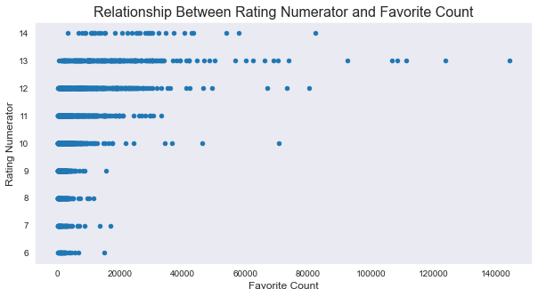

As seen in the Rating Numerator vs Favorite Count plot above, higher ratings usually have higher favorite counts.

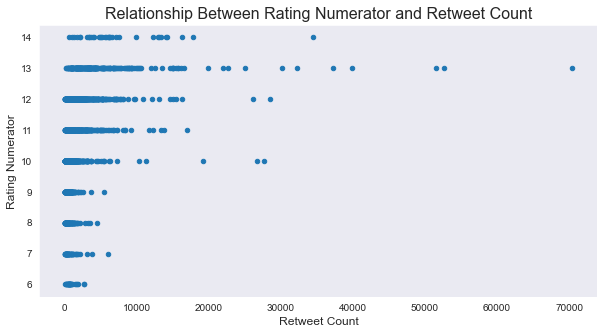

The Rating Numerator vs Retweet Count plot above shows that higher ratings usually have higher retweet counts.

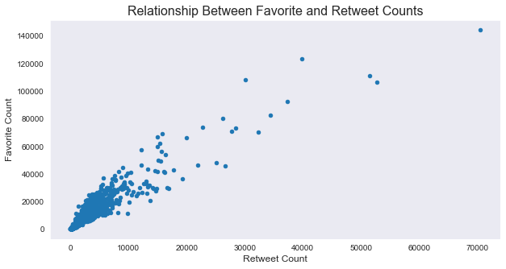

There is a positive correlation between favorite count and retweet count, as seen in the Favorite Count vs Retweet Count plot above.

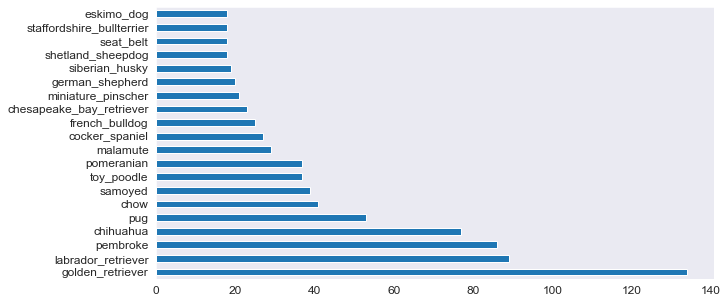

The most rated dog breed is the Golden Retriever.